# 2018 Togiak Herring Spawning and ASL

Greg Buck

October 3, 2018

## Spawning Biomass

Total spawning biomass is estimated as the sum of the peak aerial survey (2 May 2018), total sac roe harvest up till the date of peak areial survey and a post season survey. For 2018 this yields a total spawning biomass of 16,001 tons.

| Description | Biomass |
| --- | --- |
| Peak Survey | 3,375 |
| Pre-Peak Harvest | 10,669 |
| Post-Harvest Survey | 1,957 |

I strongly suspect the total run biomass thusly calculated is roughly one order of magnatude too small and would therefore rate it a very poor estimate for ASA model forecast purposes. I think poor weather conditions played a part in low-ball survey estimates. Also, this year we appear to have a harvest that peaked on 1 May while the surveys suggest biomass might have peaked several days after the harvest. This might also have thrown off our spawning biomass calculations.

Usually by the end of our sampling our samples have a fairly high % of spawned out fish. This year we collected a gillnet sample from very late in the season (5/16) and I was struck by the fact that even that late in the season most of the fish were still ripe. I suspect that we had a very unusual timing in 2018 with the fish showing up early but spawning late. This is possible as I think ocean temps on the shelf break in late Feburary and early March are what set the the migration timing but temperatures actually on the spawning grounds determine spawning time.

Our run biomass calculations–to some extent–depend on a spawning biomass that peaks sharply and falls away rapidly and our ability to measure the same. A long protracted run without much of a defined peak might cause us real problems in the biomass estimating department.

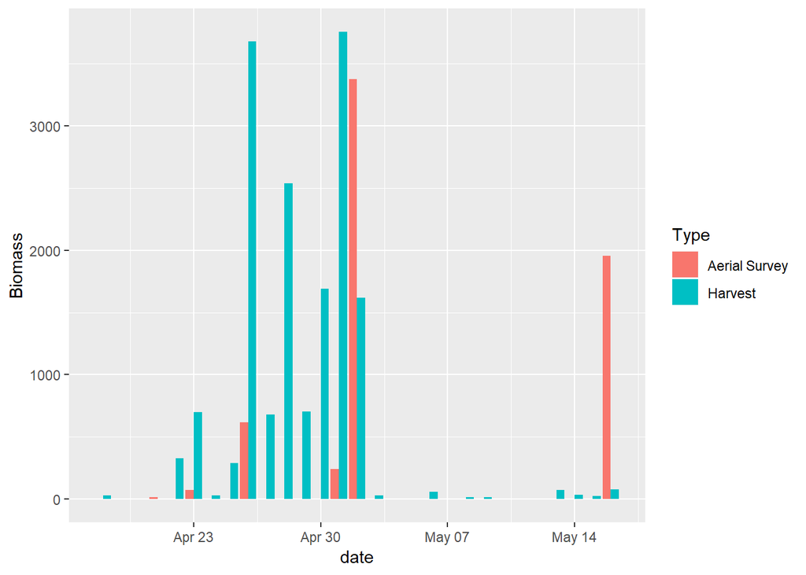

## 2018 ASL

```
##
##    4    5    6    7    8    9   10   11   12   13   14   16   17
##  947 1349  559  791  924  761  584  338  123   48   14    1    1
```

Comparing the 2018 weight at age with historical ASL (2008-2017):

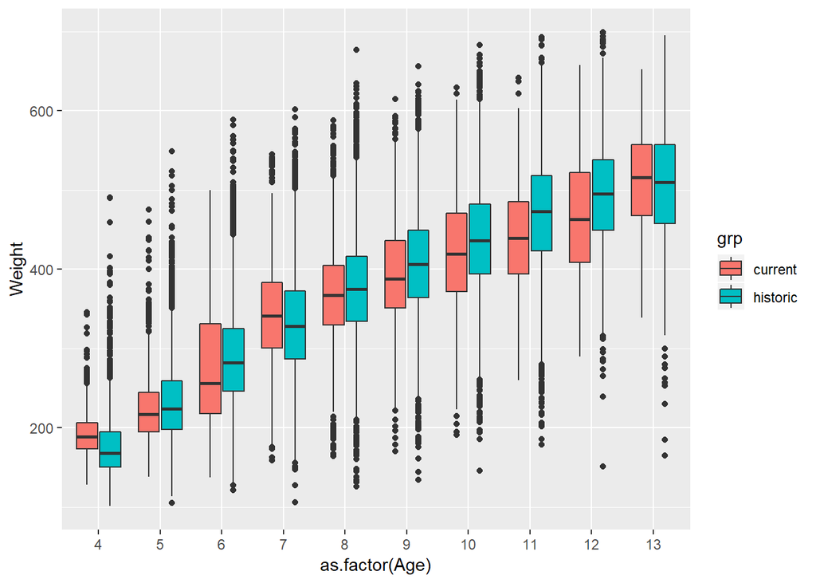

Mean and Standard Deviation of current (2018) and historic (2008-2017) datasets:

```
##    Age  DataSet     Mean       SD
## 1   10  current 421.2654 72.70521
## 2   10 historic 438.1381 71.84921
## 3   11  current 442.1302 68.50871
## 4   11 historic 469.9277 74.42346
## 5   12  current 464.2033 76.94846
## 6   12 historic 494.3194 70.41190
## 7   13  current 507.8750 72.16430
## 8   13 historic 506.8287 76.56571
## 9    4  current 192.4108 28.92798
## 10   4 historic 180.7548 50.12312
## 11   5  current 224.1742 42.88426
## 12   5 historic 234.3865 54.62251
## 13   6  current 274.7496 74.97066
## 14   6 historic 289.5298 61.43598
## 15   7  current 339.9469 71.45989
## 16   7 historic 332.3423 63.59769
## 17   8  current 369.2056 69.24159
## 18   8 historic 376.7922 63.78720
## 19   9  current 394.8725 69.61852
## 20   9 historic 406.5841 65.48632
```

### Sample groups

Frequency table by subdistrict and sample date (subdistrict: 12=nunavachak, 21=hagemeister, 70=togiak)(Gear: 4=gillnet, 5=purse seine):

```
##                10  12  21  70
##
## 4 2018-04-22    0   0   0   0
##   2018-04-23    0   0   0   0
##   2018-04-24    0   0   0   0
##   2018-04-25    0   0   0   0
##   2018-04-26    0   0   0   0
##   2018-04-27    0   0   0   0
##   2018-04-28    0   0   0   0
##   2018-04-29    0   0   0   0
##   2018-04-30    0   0   0   0
##   2018-05-01  156   0   0   0
##   2018-05-02    0   0   0   0
##   2018-05-16   76   0   0   0
## 5 2018-04-22    0   0   0 358
##   2018-04-23    0 716   0   0
##   2018-04-24    0   0 335   0
##   2018-04-25    0   0 349   0
##   2018-04-26    0 303 332   0
##   2018-04-27    0   0 341   0
##   2018-04-28    0 451 344   0
##   2018-04-29    0 365 357   0
##   2018-04-30    0 341 330   0
##   2018-05-01    0 351 354   0
##   2018-05-02    0 225 343   0
##   2018-05-16    0   0   0   0
```

We only have enough for one sample group for the gillnet harvest. Most of the harvest and our sampling effort occured in Hagemeister and Nunavachak subdistricts. There was little difference between the age composition of these two subdistricts (12=Nunavachak, 21=Hagemeister):

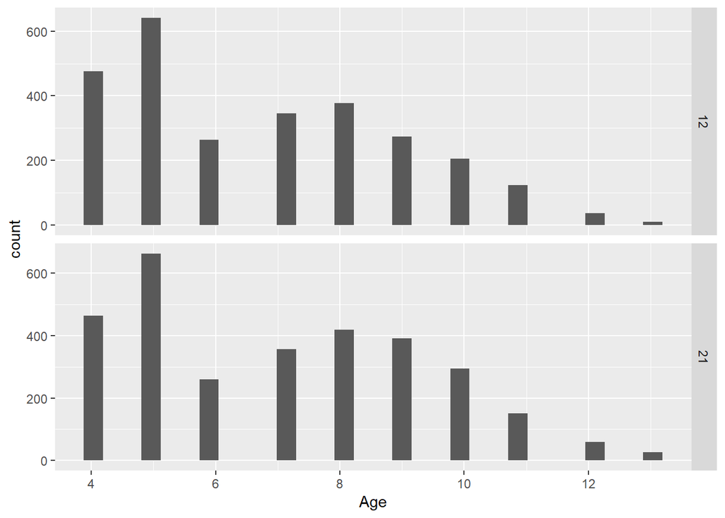

Therefore, I decide to stratify the 2018 biomass by time but not spatially (east vs. west). After some exploration I decide to stratify into 6 purse seine sampling groups:

[output not shown]

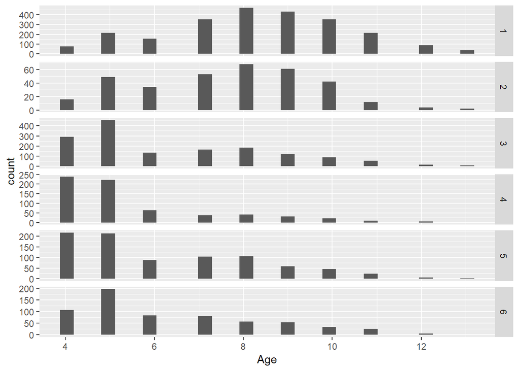

##### A few notes:

There was a sharp shift 4/26 or 4/27 after which the larger age classes disappear. Also, there is a very large age 4-6 signal that persisted across the entire season—suggesting that a large recruitment event ~4 years ago is starting to show up in the harvest.